# 1. Make classification data and get it ready

```python
import sklearn
```

```python
from sklearn.datasets import make_circles

# Make 2000 samples
n_samples = 1000

X, y = make_circles(n_samples,
                     noise = 0.03,
                     random_state=42)

len(X), len(y)
```

```
(1000, 1000)
```

```python
print(f"First 5 sample of X: /n {X[:5]}")
print(f"First 5 sample of y:/n {y[:5]}")
```

```
First 5 sample of X: /n [[ 0.75424625  0.23148074]
 [-0.75615888  0.15325888]
 [-0.81539193  0.17328203]
 [-0.39373073  0.69288277]
 [ 0.44220765 -0.89672343]]
First 5 sample of y:/n [1 1 1 1 0]
```

```python
#Make DataFrame of circle data

import pandas as pd
circles = pd.DataFrame({"X1":X[:,0],
                        "X2" : X[:,1],
                        "label" : y})

circles.head()
```

|  | X1 | X2 | label |
| --- | --- | --- | --- |
| 0 | 0.754246 | 0.231481 | 1 |
| 1 | -0.756159 | 0.153259 | 1 |
| 2 | -0.815392 | 0.173282 | 1 |
| 3 | -0.393731 | 0.692883 | 1 |
| 4 | 0.442208 | -0.896723 | 0 |

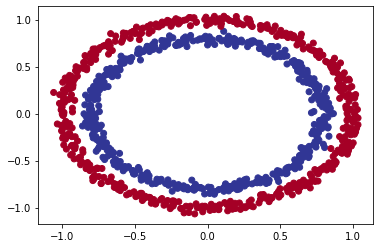

```python
# Visualize
import matplotlib.pyplot as plt
plt.scatter(x=X[:,0],y=X[:, 1], c=y , cmap=plt.cm.RdYlBu)
```

```python
### 1.1. Check input and output data shapes
```

```python
X.shape, y.shape
```

```
((1000, 2), (1000,))
```

```python
X
```

```
array([[ 0.75424625,  0.23148074],
       [-0.75615888,  0.15325888],
       [-0.81539193,  0.17328203],
       ...,
       [-0.13690036, -0.81001183],
       [ 0.67036156, -0.76750154],
       [ 0.28105665,  0.96382443]])
```

```python
# View the first example of features and labels
X_sample = X[0]
y_sample = y[0]

print(f"Values for one sample of X: {X_sample} and the same for y: {y_sample}")
print(f"Shapes for one sample of X: {X_sample.shape} and the same for y: {y_sample.shape}")
```

```
Values for one sample of X: [0.75424625 0.23148074] and the same for y: 1
Shapes for one sample of X: (2,) and the same for y: ()
```

## 1.2 Turen data into tensors and create train test dataset

```python
import torch
torch.__version__
```

```
'1.13.1+cu116'
```

```python
type(X), X.dtype
```

```
(numpy.ndarray, dtype('float64'))
```

```python
# Turn data into tensors
X = torch.from_numpy(X).type(torch.float)
y = torch.from_numpy(y).type(torch.float)
```

```python
type(X), X.dtype
```

```
(torch.Tensor, torch.float32)
```

```python
# Split the data into traiing and test sets
from sklearn.model_selection import train_test_split

X_train, X_test, y_train, y_test = train_test_split(X,y,test_size = 0.2, random_state = 42)
```

```python
len(X_train), len(X_test), len(y_train), len(y_test)
```

```
(800, 200, 800, 200)
```

```python
n_samples
```

```
1000
```

# 2. Building a model

Buikding a model to classify our blue and red dots

what to do?

1. setup device agonistic code so our code will run on accelerator (GPU) if there is one
2. Construct a model
3. Define a loss function and optimizer
4. Create a training and test loop

```python
from sklearn import model_selection
# Import PyTorch and nn
import torch
from torch import nn

# Make device agnostic code
device = "cuda" if torch.cuda.is_available() else "cpu"
```

1. Subclasses `nn.Module` (almost all models in PyTorch subclass `nn.Module`)
2. Create nn.Linear layers that are capable of handling the shapes of our data
3. Defines a forward() method that outlines the forward pass( or forward computaion) of the model_selection
4. Instatisate an instance of our model class and send it to the target `device`

```python
class CircleModelV0(nn.Module):
  def __init__(self):
    super().__init__()
    self.layer_1 = nn.Linear(in_features =2 , out_features = 5) # Two features and upscales to 5 features
    self.layer_2 = nn.Linear(in_features =5 , out_features = 1) # five features and output 1 features

    # self.two_linear_layers = model_0 = nn.Sequential(
    # nn.Linear(in_features =2 , out_features = 5),
    # nn.Linear(in_features =5 , out_features = 1)
    # )


  def forward(self,x):
    return self.layer_2(self.layer_1(x))

model_0 = CircleModelV0().to(device)
model_0
```

```
CircleModelV0(
  (layer_1): Linear(in_features=2, out_features=5, bias=True)
  (layer_2): Linear(in_features=5, out_features=1, bias=True)
)
```

```python
next(model_0.parameters()).device
```

```
device(type='cpu')
```

```python
# Let's replicate the model above using nn.Squential

model_0 = nn.Sequential(
    nn.Linear(in_features =2 , out_features = 5),
    nn.Linear(in_features =5 , out_features = 1)
).to(device)
```

```python
model_0.state_dict()
```

```
OrderedDict([('0.weight', tensor([[-0.0829, -0.2872],
                      [ 0.4691, -0.5582],
                      [-0.3260, -0.1997],
                      [-0.4252,  0.0667],
                      [-0.6984,  0.6386]])),
             ('0.bias', tensor([-0.6007,  0.5459,  0.1177, -0.2296,  0.4370])),
             ('1.weight',
              tensor([[ 0.0697,  0.3613,  0.0489, -0.1410,  0.1202]])),
             ('1.bias', tensor([-0.1213]))])
```

```python
untrained_preds = model_0(X_test.to(device))
print(f"Length if predictions: {len(untrained_preds)}, Shape: {untrained_preds.shape}")
print(f"Length if test samples: {len(X_test)}, Shape: {X_test.shape}")
print(f"First 10 predictions: {untrained_preds[:10]}")
print(f"First 10 labels: {y_test[:10]}")
```

```
Length if predictions: 200, Shape: torch.Size([200, 1])
Length if test samples: 200, Shape: torch.Size([200, 2])
First 10 predictions: tensor([[-0.0338],
        [-0.0309],
        [ 0.0894],
        [-0.0692],
        [ 0.2967],
        [ 0.2968],
        [ 0.1405],
        [ 0.2178],
        [ 0.0805],
        [-0.0284]], grad_fn=<SliceBackward0>)
First 10 labels: tensor([1., 0., 1., 0., 1., 1., 0., 0., 1., 0.])
```

## 2.1 Stup loss function and optimizer

```python
# Stup the loss functuion
# loss_fn = nn.BCELoss() # BCELoss = requires inputs to have gone the sigmoid activation functuin prior to input to BCE loss
loss_fn = nn.BCEWithLogitsLoss() # BCE with logits loss sigmoid activation function built-in


optimizer = torch.optim.SGD(params=model_0.parameters(), lr=0.01)
```

```python
# calcultate accuracy
def accuracy_fn(y_true, y_pred):
  correct = torch.eq(y_true, y_pred).sum().item()
  acc =(correct/len(y_pred)) * 100
  return acc
```

# 3. Train Model

To train model we are going to need to build a training loop with flowing tests

1. Forward pass
2. calculate the loss
3. Optimizer zero grad
4. Loss Backward
5. optimizer

## 3.1 Going from raw logists -> prediction probabilities -> prediction labels

Our model outputs are going to be raw *logits*

We can convert these **logits** into prediction probabilities by passing them to some kind of activation function ( e.g. sigmoid for binary crossenthropy and softmax for multiclasss classification)

Then we can convert our model's prediction probabilities to prediction labels by either rounding them or taking the `argmax()`

```python
# View the first outputs of the forward pass on the test data
y_logits = model_0(X_test.to(device)[:5])
y_logits
```

```
tensor([[-0.0338],
        [-0.0309],
        [ 0.0894],
        [-0.0692],
        [ 0.2967]], grad_fn=<AddmmBackward0>)
```

```python
y_test[:5]
```

```
tensor([1., 0., 1., 0., 1.])
```

```python
#use the sigmoid function on out modle logits to turn them to prediction propbablities
y_pred_prob = torch.sigmoid(y_logits)
y_pred_prob
```

```
tensor([[0.4916],
        [0.4923],
        [0.5223],
        [0.4827],
        [0.5736]], grad_fn=<SigmoidBackward0>)
```

For our prediction probability values, we need to perform a range-style rounding on them:

- `y_pred_probs` >= 0.5, `y=1` (class 1)
- `y_pred_probs` < 0.5, `y=0` (class 0)

```python
#Find the redicted labels
y_preds = torch.round(y_pred_prob)

#In full
y_pred_labels = torch.round(torch.sigmoid(model_0(X_test.to(device))[:5]))

# Check for equality
print(torch.eq(y_preds.squeeze(), y_pred_labels.squeeze()))

# Get rid of extra dimension
y_preds.squeeze()
```

```
tensor([True, True, True, True, True])
```

```
tensor([0., 0., 1., 0., 1.], grad_fn=<SqueezeBackward0>)
```

### Building a training and testing loop

```python
device
```

```
'cpu'
```

```python
!nvidia-smi
```

```
NVIDIA-SMI has failed because it couldn't communicate with the NVIDIA driver. Make sure that the latest NVIDIA driver is installed and running.
```

```python
torch.cuda.manual_seed(42)

# Set the number of epochs
epochs = 2000

# Put data to target device
X_train, X_test, y_train , y_test = X_train.to(device), X_test.to(device), y_train.to(device) , y_test.to(device)

for epoch in range(epochs):

  # Training
  model_0.train()

  # Forward Pass
  y_logits = model_0(X_train).squeeze()
  y_preds = torch.round(torch.sigmoid(y_logits))


  # Calcultate Loss/Accuracy
  # loss = loss_fn(torch.sigmoid(y_logits))
  loss = loss_fn(y_logits, y_train)
  accuracy = accuracy_fn(y_true= y_train, y_pred = y_preds)


  # optimizer zero grad # prevent accumulating
  optimizer.zero_grad()


  # loss backward -> backpropagation to find gradient
  loss.backward()


  #optimizer step -> gradint decent
  optimizer.step()

  #Testing
  model_0.eval()

  with torch.inference_mode():
    # forward pass
    test_logits = model_0(X_test).squeeze()
    test_pred = torch.round(torch.sigmoid(test_logits))


    #Calculate the test loss/accuracy

    test_loss = loss_fn(test_logits, y_test)
    test_acc = accuracy_fn(y_true = y_test, y_pred=test_pred)

  if(epoch %10 == 0 ):
    print(f"Epoch: {epoch}     Loss: {loss:.5f}     Acc: {accuracy:.2f}%      Test loss:{test_loss:.5f}     Test Accuracy: {test_acc:.2f}%")
```

```
Epoch: 0     Loss: 0.69796     Acc: 51.88%      Test loss:0.69460     Test Accuracy: 57.50%
Epoch: 10     Loss: 0.69768     Acc: 52.00%      Test loss:0.69438     Test Accuracy: 58.00%
Epoch: 20     Loss: 0.69742     Acc: 52.00%      Test loss:0.69418     Test Accuracy: 57.50%
Epoch: 30     Loss: 0.69717     Acc: 52.00%      Test loss:0.69401     Test Accuracy: 56.50%
Epoch: 40     Loss: 0.69695     Acc: 51.62%      Test loss:0.69385     Test Accuracy: 56.50%
Epoch: 50     Loss: 0.69675     Acc: 51.38%      Test loss:0.69370     Test Accuracy: 56.00%
Epoch: 60     Loss: 0.69656     Acc: 51.38%      Test loss:0.69357     Test Accuracy: 56.00%
Epoch: 70     Loss: 0.69638     Acc: 51.38%      Test loss:0.69345     Test Accuracy: 56.50%
Epoch: 80     Loss: 0.69621     Acc: 51.25%      Test loss:0.69334     Test Accuracy: 56.50%
Epoch: 90     Loss: 0.69606     Acc: 51.38%      Test loss:0.69324     Test Accuracy: 55.00%
Epoch: 100     Loss: 0.69592     Acc: 51.12%      Test loss:0.69315     Test Accuracy: 54.00%
Epoch: 110     Loss: 0.69579     Acc: 51.00%      Test loss:0.69306     Test Accuracy: 53.00%
Epoch: 120     Loss: 0.69567     Acc: 51.12%      Test loss:0.69299     Test Accuracy: 52.50%
Epoch: 130     Loss: 0.69555     Acc: 51.50%      Test loss:0.69292     Test Accuracy: 52.00%
Epoch: 140     Loss: 0.69544     Acc: 51.38%      Test loss:0.69286     Test Accuracy: 52.00%
Epoch: 150     Loss: 0.69534     Acc: 51.62%      Test loss:0.69280     Test Accuracy: 52.00%
Epoch: 160     Loss: 0.69525     Acc: 51.38%      Test loss:0.69275     Test Accuracy: 51.50%
Epoch: 170     Loss: 0.69516     Acc: 51.25%      Test loss:0.69270     Test Accuracy: 51.00%
Epoch: 180     Loss: 0.69507     Acc: 51.62%      Test loss:0.69266     Test Accuracy: 52.00%
Epoch: 190     Loss: 0.69500     Acc: 51.62%      Test loss:0.69262     Test Accuracy: 51.50%
Epoch: 200     Loss: 0.69492     Acc: 51.62%      Test loss:0.69259     Test Accuracy: 50.50%
Epoch: 210     Loss: 0.69485     Acc: 51.62%      Test loss:0.69255     Test Accuracy: 50.00%
Epoch: 220     Loss: 0.69478     Acc: 51.62%      Test loss:0.69253     Test Accuracy: 49.50%
Epoch: 230     Loss: 0.69472     Acc: 51.62%      Test loss:0.69250     Test Accuracy: 49.50%
Epoch: 240     Loss: 0.69466     Acc: 52.00%      Test loss:0.69248     Test Accuracy: 49.50%
Epoch: 250     Loss: 0.69461     Acc: 52.00%      Test loss:0.69245     Test Accuracy: 49.50%
Epoch: 260     Loss: 0.69455     Acc: 51.75%      Test loss:0.69244     Test Accuracy: 49.50%
Epoch: 270     Loss: 0.69450     Acc: 51.25%      Test loss:0.69242     Test Accuracy: 49.50%
Epoch: 280     Loss: 0.69445     Acc: 51.25%      Test loss:0.69240     Test Accuracy: 49.50%
Epoch: 290     Loss: 0.69441     Acc: 50.88%      Test loss:0.69239     Test Accuracy: 49.00%
Epoch: 300     Loss: 0.69436     Acc: 51.00%      Test loss:0.69238     Test Accuracy: 49.00%
Epoch: 310     Loss: 0.69432     Acc: 51.12%      Test loss:0.69237     Test Accuracy: 49.00%
Epoch: 320     Loss: 0.69428     Acc: 51.12%      Test loss:0.69236     Test Accuracy: 49.50%
Epoch: 330     Loss: 0.69424     Acc: 51.12%      Test loss:0.69235     Test Accuracy: 49.50%
Epoch: 340     Loss: 0.69421     Acc: 51.25%      Test loss:0.69234     Test Accuracy: 49.50%
Epoch: 350     Loss: 0.69417     Acc: 51.38%      Test loss:0.69234     Test Accuracy: 49.50%
Epoch: 360     Loss: 0.69414     Acc: 51.38%      Test loss:0.69233     Test Accuracy: 49.50%
Epoch: 370     Loss: 0.69411     Acc: 51.50%      Test loss:0.69233     Test Accuracy: 50.00%
Epoch: 380     Loss: 0.69408     Acc: 51.25%      Test loss:0.69232     Test Accuracy: 50.50%
Epoch: 390     Loss: 0.69405     Acc: 50.88%      Test loss:0.69232     Test Accuracy: 50.50%
```

[output cut: 145 more lines]

```
Epoch: 1850     Loss: 0.69312     Acc: 51.50%      Test loss:0.69327     Test Accuracy: 48.50%
Epoch: 1860     Loss: 0.69312     Acc: 51.00%      Test loss:0.69328     Test Accuracy: 48.50%
Epoch: 1870     Loss: 0.69312     Acc: 51.00%      Test loss:0.69328     Test Accuracy: 49.00%
Epoch: 1880     Loss: 0.69312     Acc: 51.00%      Test loss:0.69329     Test Accuracy: 49.00%
Epoch: 1890     Loss: 0.69312     Acc: 51.25%      Test loss:0.69329     Test Accuracy: 49.50%
Epoch: 1900     Loss: 0.69311     Acc: 51.38%      Test loss:0.69330     Test Accuracy: 49.50%
Epoch: 1910     Loss: 0.69311     Acc: 51.50%      Test loss:0.69330     Test Accuracy: 50.00%
Epoch: 1920     Loss: 0.69311     Acc: 51.38%      Test loss:0.69331     Test Accuracy: 49.50%
Epoch: 1930     Loss: 0.69311     Acc: 51.50%      Test loss:0.69331     Test Accuracy: 50.00%
Epoch: 1940     Loss: 0.69311     Acc: 51.38%      Test loss:0.69332     Test Accuracy: 50.50%
Epoch: 1950     Loss: 0.69311     Acc: 51.38%      Test loss:0.69332     Test Accuracy: 50.50%
Epoch: 1960     Loss: 0.69311     Acc: 51.25%      Test loss:0.69333     Test Accuracy: 50.50%
Epoch: 1970     Loss: 0.69311     Acc: 50.75%      Test loss:0.69333     Test Accuracy: 50.50%
Epoch: 1980     Loss: 0.69311     Acc: 50.62%      Test loss:0.69334     Test Accuracy: 50.00%
Epoch: 1990     Loss: 0.69311     Acc: 50.62%      Test loss:0.69334     Test Accuracy: 50.00%
```

# 4. Make predictions and evaluate the model

From the metrics it looks like our model learns nothing

So to inspect it let's make some predictions and make them visual

In other words, "Visualize"

To do so we are going to use `plot decision boundary`

```python
import requests
from pathlib import Path

# Download helper functions from learn pytorch repo
if Path("helper_functions.py").is_file():
  print("helper_function.py already exists, skiping download")
else:
  print("Downlading helper function")
  request  = requests.get("https://raw.githubusercontent.com/mrdbourke/pytorch-deep-learning/main/helper_functions.py")
  with open("helper_functions.py","wb") as f :
    f.write(request.content)

from helper_functions import plot_predictions, plot_decision_boundary
```

```
helper_function.py already exists, skiping download
```

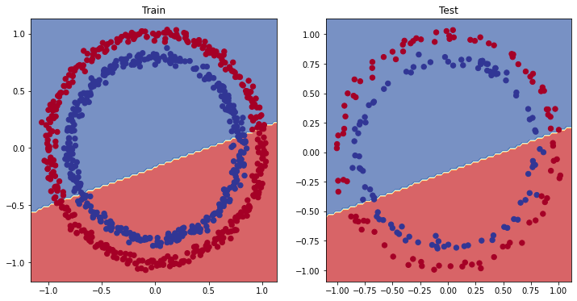

```python
# Plot decision boundary of the mode
plt.figure(figsize=(12,6))
plt.subplot(1,2,1)
plt.title("Train")
plot_decision_boundary(model_0, X_train, y_train)
plt.subplot(1,2,2)
plt.title("Test")
plot_decision_boundary(model_0, X_test, y_test)
```

# 5. Improving a model( from a model perspective)

- Add more layers - give the model more chances to learn more patterns in the data
- Add more hidden units - go form 5 to 10 hiddenlayers
- Fit for longer
- Changing the activation functions
- Change the learning rate -> if it is exploding gradient problem

These are model's perspective

data's perspective model improvement also there

```python
# More numbers to adjust -> more opertunity to learn the target
class CircleModelV1(nn.Module):
  def __init__(self):
    super().__init__()
    self.layer_1 = nn.Linear(in_features = 2, out_features = 10)
    self.layer_2 = nn.Linear(in_features = 10, out_features = 10)
    self.layer_3= nn.Linear(in_features = 10, out_features = 1)

  def forward(self,x):
    return self.layer_3(self.layer_2(self.layer_1(x)))

model_1 = CircleModelV1().to(device)
model_1
```

```
CircleModelV1(
  (layer_1): Linear(in_features=2, out_features=10, bias=True)
  (layer_2): Linear(in_features=10, out_features=10, bias=True)
  (layer_3): Linear(in_features=10, out_features=1, bias=True)
)
```

```python
# Create a loss function
loss_fn = nn.BCEWithLogitsLoss()
# Create an optimizer
optimizer = torch.optim.SGD(params=model_1.parameters(), lr=0.1)
```

```python
# Write a training and evaluation loop for model_1
torch.manual_seed(42)
torch.cuda.manual_seed(42)

# Train for longer
epochs = 1000


# Put data on the target device
X_train , y_train = X_train.to(device) , y_train.to(device)
X_test , y_test = X_test.to(device) , y_test.to(device)

for epoch in range(epochs):
  ## Training
  model_1.train()

  #Forward oass
  y_logits = model_1(X_train).squeeze()
  y_pred = torch.round(torch.sigmoid(y_logits))


  #2. Calculate the loss/acc
  loss = loss_fn(y_logits, y_train)
  acc = accuracy_fn(y_true=y_train, y_pred = y_pred)

  #3. optimizer zero grad
  optimizer.zero_grad()

  #4. Loss backward (backpropagation)
  loss.backward()

  #5 Optimizer step
  optimizer.step()

  ### Testing
  model_1.eval()

  with torch.inference_mode():
    test_y_logits = model_1(X_test).squeeze()
    pred_y_pred = torch.round(torch.sigmoid(test_y_logits))
    pred_loss = loss_fn(test_y_logits, y_test)
    pred_acc = accuracy_fn(y_true = y_test, y_pred= pred_y_pred)

  if(epoch % 100 == 0):
    print(f"Loss  {loss:5f}  ;  Accuracy : {acc:2f}%  ; Test_loss : {pred_loss:.5f}   ;   Test_accuracy : {pred_acc:2f}% ")
```

```
Loss  0.697126  ;  Accuracy : 50.000000%  ; Test_loss : 0.69594   ;   Test_accuracy : 50.000000%
Loss  0.693272  ;  Accuracy : 49.625000%  ; Test_loss : 0.69334   ;   Test_accuracy : 54.000000%
Loss  0.693115  ;  Accuracy : 49.875000%  ; Test_loss : 0.69357   ;   Test_accuracy : 50.000000%
Loss  0.693045  ;  Accuracy : 50.625000%  ; Test_loss : 0.69384   ;   Test_accuracy : 49.500000%
Loss  0.693012  ;  Accuracy : 50.500000%  ; Test_loss : 0.69407   ;   Test_accuracy : 46.000000%
Loss  0.692995  ;  Accuracy : 51.000000%  ; Test_loss : 0.69425   ;   Test_accuracy : 47.500000%
Loss  0.692987  ;  Accuracy : 51.500000%  ; Test_loss : 0.69438   ;   Test_accuracy : 47.000000%
Loss  0.692983  ;  Accuracy : 50.875000%  ; Test_loss : 0.69447   ;   Test_accuracy : 46.500000%
Loss  0.692982  ;  Accuracy : 51.000000%  ; Test_loss : 0.69453   ;   Test_accuracy : 46.000000%
Loss  0.692981  ;  Accuracy : 51.500000%  ; Test_loss : 0.69458   ;   Test_accuracy : 46.000000%
```

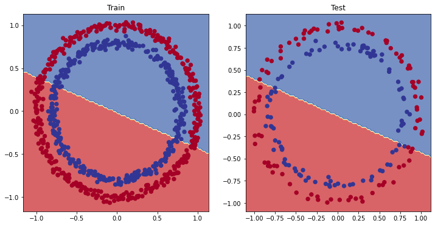

```python
# Plot decision boundary of the mode
plt.figure(figsize=(12,6))
plt.subplot(1,2,1)
plt.title("Train")
plot_decision_boundary(model_1, X_train, y_train)
plt.subplot(1,2,2)
plt.title("Test")
plot_decision_boundary(model_1, X_test, y_test)
```

## 5.1 Preparing data to see if our model can fit a straight line

One way to troubleshoot to a larger problem is to test out a smaller problem.

```python
# create *known* parameters

weight = 0.7
bias = 0.3


#create
start = 0
end = 1
step = 0.02
X_reg = torch.arange(start,end,step).unsqueeze(dim=1)
y_reg = weight * X_reg + bias

X_reg[:10] , y_reg[:10]
```

```
(tensor([[0.0000],
         [0.0200],
         [0.0400],
         [0.0600],
         [0.0800],
         [0.1000],
         [0.1200],
         [0.1400],
         [0.1600],
         [0.1800]]), tensor([[0.3000],
         [0.3140],
         [0.3280],
         [0.3420],
         [0.3560],
         [0.3700],
         [0.3840],
         [0.3980],
         [0.4120],
         [0.4260]]))
```

```python
train_split = int(0.8*len(X_reg))

X_reg_train, y_reg_train = X_reg[:train_split] , y_reg[:train_split]
X_reg_test, y_reg_test = X_reg[train_split:] , y_reg[train_split:]

len(X_reg_train), len(y_reg_train), len(X_reg_test), len(y_reg_test)
```

```
(40, 40, 10, 10)
```

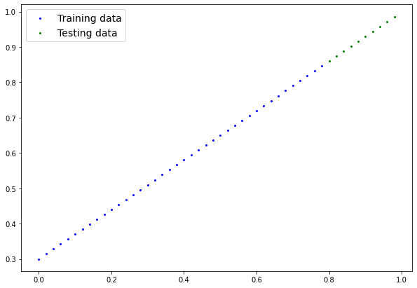

```python
# Plot decision boundary of the mode
plot_predictions(train_data=X_reg_train, train_labels=y_reg_train, test_data = X_reg_test, test_labels =y_reg_test )
```

## 5.2 Adjusting `model_1` to fit a straight line

```python
model_2 = nn.Sequential(
    nn.Linear(in_features = 1, out_features=10, bias = True),
    nn.Linear(in_features = 10, out_features=10, bias = True),
    nn.Linear(in_features = 10, out_features=1, bias = True),
)

# Loss and optimizer
loss_fn = nn.L1Loss()
optimizer = torch.optim.SGD(params = model_2.parameters(), lr=0.1)
```

```python
# Train the model
torch.manual_seed(42)
torch.cuda.manual_seed(42)

#Set the number of epochs
epochs = 1000


# Put the data on the target device
X_reg_train,y_reg_train = X_reg_train.to(device),y_reg_train.to(device)
X_reg_test,y_reg_test = X_reg_test.to(device),y_reg_test.to(device)

# Training

for epoch in range(epochs):
  model_2.train()
  y_pred = model_2(X_reg_train)
  loss = loss_fn(y_pred, y_reg_train)
  optimizer.zero_grad()
  loss.backward()
  optimizer.step()

  model_2.eval()
  with torch.inference_mode():
    test_pred = model_2(X_reg_test)
    test_loss = loss_fn(test_pred, y_reg_test)

  if(epoch%100 == 0):
    print(f"Epoch: {epoch}     Loss: {loss:.5f}      Test loss: {test_loss:.5f}")
```

```
Epoch: 0     Loss: 0.75792      Test loss: 0.54143
Epoch: 100     Loss: 0.07424      Test loss: 0.00881
Epoch: 200     Loss: 0.07601      Test loss: 0.01785
Epoch: 300     Loss: 0.06932      Test loss: 0.03021
Epoch: 400     Loss: 0.06326      Test loss: 0.01104
Epoch: 500     Loss: 0.05926      Test loss: 0.01172
Epoch: 600     Loss: 0.05980      Test loss: 0.02428
Epoch: 700     Loss: 0.04829      Test loss: 0.02345
Epoch: 800     Loss: 0.04891      Test loss: 0.00572
Epoch: 900     Loss: 0.06723      Test loss: 0.00978
```

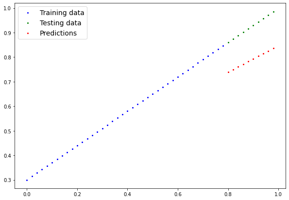

```python
# Plot decision boundary of the mode
with torch.inference_mode():
    preds = model_2(X_reg_test)

plot_predictions(train_data=X_reg_train, train_labels=y_reg_train, test_data = X_reg_test, test_labels =y_reg_test, predictions = preds.cpu() )
```

# 6. The missing piece : non linarity

"What patters could you use draw if you guven an infinite amount of a straight and non-straight lines?"

Or in machine learning terms, an infinite learning terms, an infinite (But really it is finite) of non -linear functions?

## 6.1 Recreating non-linear data(red and blue circle

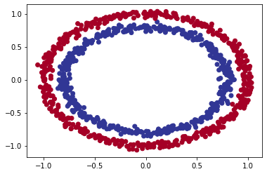

```python
n_samples = 1000

X,y = make_circles(n_samples, noise=0.03, random_state=42)

plt.scatter(X[:,0], X[:,1],c=y, cmap=plt.cm.RdYlBu)
```

```python
# Convert data to tensors and then split to train and test

# Convert into tensors
X = torch.from_numpy(X).type(torch.float)
y = torch.from_numpy(y).type(torch.float)

# split into train test
X_train, X_test, y_train, y_test = train_test_split(X, y , test_size = 0.2 ,random_state=42)
```

## 6.2 Building a model with non-liniarity

Linear = straight line

Non-Linear = Non straight line

```python
class CircleModelV2(nn.Module):
  def __init__ (self):
    super().__init__()
    self.layer_1 = nn.Linear(in_features=2, out_features=10)
    self.layer_2 = nn.Linear(in_features=10, out_features=10)
    self.layer_3 = nn.Linear(in_features=10, out_features=1)
    self.relu = nn.ReLU()

  def forward(self, x):
    return self.layer_3(self.relu(self.layer_2(self.relu(self.layer_1(x)))))


model_3 = CircleModelV2().to(device)
model_3
```

```
CircleModelV2(
  (layer_1): Linear(in_features=2, out_features=10, bias=True)
  (layer_2): Linear(in_features=10, out_features=10, bias=True)
  (layer_3): Linear(in_features=10, out_features=1, bias=True)
  (relu): ReLU()
)
```

```python
## Setup loss function and optimizer

loss_fn = nn.BCEWithLogitsLoss()
optimizer = torch.optim.SGD(model_3.parameters(), lr=0.1)
```

## 6.3 Training and testing loop

```python
X_train, X_test, y_train, y_test = X_train.to(device), X_test.to(device), y_train.to(device), y_test.to(device)
```

```python
epochs = 1000

for epoch in range(epochs):
  model_3.train()

  #forward pass
  y_logits = model_3(X_train)
  y_preds = torch.round(torch.sigmoid(y_logits))

  #loss
  loss = loss_fn(y_logits.squeeze(), y_train)
  acc = accuracy_fn(y_true=y_train, y_pred = y_preds.squeeze())

  #Optimizer zero grad
  optimizer.zero_grad()

  #Backward
  loss.backward()

  #optimizer step
  optimizer.step()

  #evaluation
  model_3.eval()
  with torch.inference_mode():
    pred_logits = model_3(X_test)
    pred_preds =torch.round( torch.sigmoid(pred_logits))

    # prediction loss
    pred_loss = loss_fn(pred_logits.squeeze(), y_test)
    pred_acc = accuracy_fn(y_true = y_test, y_pred=pred_preds.squeeze())

  if(epoch % 100 == 0):
    print(f"Epoch: {epoch}    Loss: {loss:.5f}  Accuracy : {acc:.2f}%   Pred_Loss: {pred_loss}%     pred_accuracy : {pred_acc:.2f} %")
```

```
Epoch: 0    Loss: 0.69295  Accuracy : 50.00%   Pred_Loss: 0.6931881904602051%     pred_accuracy : 50.00 %
Epoch: 100    Loss: 0.69115  Accuracy : 52.88%   Pred_Loss: 0.6910240054130554%     pred_accuracy : 52.50 %
Epoch: 200    Loss: 0.68977  Accuracy : 53.37%   Pred_Loss: 0.6893961429595947%     pred_accuracy : 55.00 %
Epoch: 300    Loss: 0.68795  Accuracy : 53.00%   Pred_Loss: 0.6872316598892212%     pred_accuracy : 56.00 %
Epoch: 400    Loss: 0.68517  Accuracy : 52.75%   Pred_Loss: 0.684114933013916%     pred_accuracy : 56.50 %
Epoch: 500    Loss: 0.68102  Accuracy : 52.75%   Pred_Loss: 0.6794120669364929%     pred_accuracy : 56.50 %
Epoch: 600    Loss: 0.67515  Accuracy : 54.50%   Pred_Loss: 0.6728507876396179%     pred_accuracy : 56.00 %
Epoch: 700    Loss: 0.66659  Accuracy : 58.38%   Pred_Loss: 0.6632164716720581%     pred_accuracy : 59.00 %
Epoch: 800    Loss: 0.65160  Accuracy : 64.00%   Pred_Loss: 0.647568941116333%     pred_accuracy : 67.50 %
Epoch: 900    Loss: 0.62362  Accuracy : 74.00%   Pred_Loss: 0.6214525699615479%     pred_accuracy : 79.00 %
```

## 6.4 Evaluating a model with non-linear activation function

```python
model_3.eval()
with torch.inference_mode():
  pred_logits = model_3(X_test)
  pred_preds =torch.round( torch.sigmoid(pred_logits))
```

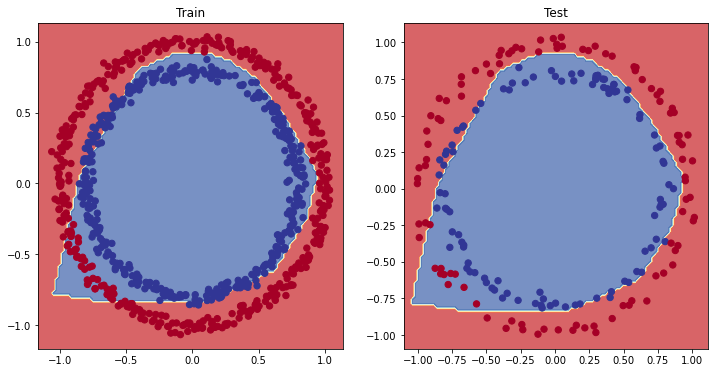

```python
# Plot decision boundary
plt.figure(figsize=(12,6))
plt.subplot(1,2,1)
plt.title("Train")
plot_decision_boundary(model_3, X_train, y_train)

plt.subplot(1,2,2)
plt.title("Test")
plot_decision_boundary(model_3, X_test, y_test)
```

# 7. Replicating non-linear activation functions

```python
# Create a tensor
A = torch.arange(-10,10,1, dtype=torch.float32)
A.dtype
```

```
torch.float32
```

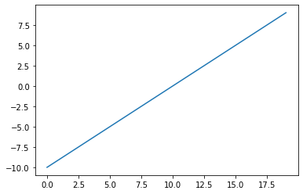

```python
plt.plot(A)
```

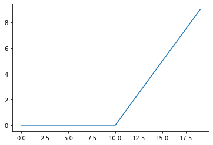

```python
plt.plot(torch.relu(A))
```

```python
def relu(x : torch.Tensor)-> torch.Tensor:
  return torch.maximum(torch.tensor(0),x)
```

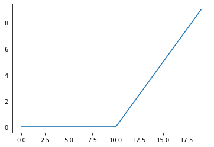

```python
plt.plot(relu(A))
```

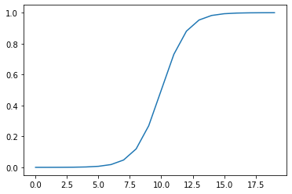

```python
plt.plot(torch.sigmoid(A))
```

## 8. Puting it all together with multi-class classification

## 8.1 Creating a toy multi-class dataset

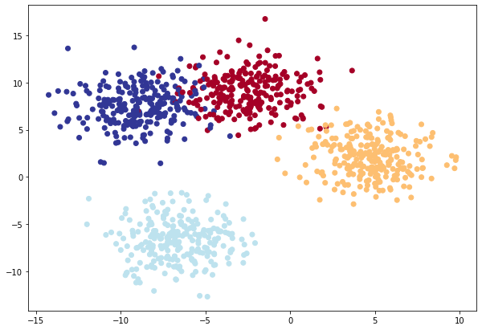

```python
# Import dependencies
import torch
import matplotlib.pyplot as plt
from sklearn.datasets import make_blobs
from sklearn.model_selection import train_test_split


NUM_CLASSES = 4
NUM_FEATURES =2
RANDOM_SEED =42

X_blob, y_blob = make_blobs(n_samples = 1000,
                            n_features  = NUM_FEATURES,
                            centers = NUM_CLASSES,
                            cluster_std=2,
                            random_state = RANDOM_SEED)


#2. Turn data into tensors
X_blob = torch.from_numpy(X_blob).type(torch.float)
y_blob = torch.from_numpy(y_blob).type(torch.LongTensor)


#3. Split into train and test

X_blob_train, X_blob_test, y_blob_train, y_blob_test = train_test_split(X_blob, y_blob, test_size = 0.2, random_state = RANDOM_SEED)


plt.figure(figsize=(10,7))
plt.scatter(X_blob[:, 0], X_blob[:,1], c=y_blob, cmap=plt.cm.RdYlBu )
```

## 8.2 Building a multiclass classification model in PyTorch

```python
# Create device agnostic code
device = "cuda" if torch.cuda.is_available() else "cpu"
```

```python
# Build a multi class classification model

class BlobModel(nn.Module):
  def __init__(self, input_features, output_features, hidden_units = 8):
    """Initializes multi-class classification model.

    Args:
      input features (int): Number of input features to the model
      output_features (int) : Number of outputs features
      hidden units (int) Number of hudden units between layers , default 8

    """
    super().__init__()

    self.linear_layer_stack = nn.Sequential(
        nn.Linear(in_features=input_features, out_features=hidden_units),
        nn.ReLU(),
        nn.Linear(in_features = hidden_units, out_features=hidden_units),
        nn.ReLU(),
        nn.Linear(in_features = hidden_units, out_features=output_features)
    )

  def forward(self,x):
    return self.linear_layer_stack(x)


model_4 = BlobModel(2,4,8).to(device)
model_4
```

```
BlobModel(
  (linear_layer_stack): Sequential(
    (0): Linear(in_features=2, out_features=8, bias=True)
    (1): ReLU()
    (2): Linear(in_features=8, out_features=8, bias=True)
    (3): ReLU()
    (4): Linear(in_features=8, out_features=4, bias=True)
  )
)
```

## 8.3 create a loss function and an optimizer

```python
# Create a loss function for multi-class classification
loss_fn = nn.CrossEntropyLoss()

# Create a optimizer for multi-class classification
optimizer = torch.optim.SGD(params= model_4.parameters(), lr = 0.1)
```

## 8.4 Getting prediction probabilities for a multi -class PyTorch model

Logits(raw output of the model) -> Pred Probs( use torch.softmax) -> Pred labels(take the argmax of the prediction probabilities)

```python
# Let's get some raw outputs of our model (logits)

model_4.eval()

with torch.inference_mode():
  preds = model_4(X_blob_test)

preds
```

```
tensor([[-4.8328e-01,  1.7778e-01, -1.0199e-01,  2.6491e-01],
        [-3.8186e-01,  7.3146e-01,  1.3069e+00,  1.2947e+00],
        [-4.0379e-01,  1.2989e-01, -2.7966e-01, -2.7260e-01],
        [-3.7996e-01, -3.1563e-02, -1.9910e-01,  3.9008e-02],
        [-4.1251e-01,  4.1885e-01,  9.4910e-01,  1.2336e+00],
        [-3.7877e-01,  9.3848e-01,  1.7169e+00,  1.6393e+00],
        [-3.6984e-01, -7.5682e-03, -2.3536e-01, -1.1451e-01],
        [-3.6578e-01,  4.0142e-01,  1.0457e+00,  1.2848e+00],
        [-3.8674e-01,  2.3680e-01, -2.9603e-01, -5.1542e-01],
        [-3.7114e-01,  3.5969e-01,  9.8532e-01,  1.2609e+00],
        [-3.6268e-01,  4.4937e-01,  1.0520e+00,  1.2246e+00],
        [-5.0195e-01,  2.0292e-01, -1.2438e-01,  3.2759e-01],
        [-3.8969e-01,  4.1438e-01,  1.0518e+00,  1.3374e+00],
        [-3.6278e-01,  4.6088e-01,  1.2801e+00,  1.5547e+00],
        [-3.6326e-01,  4.8519e-01,  1.3896e+00,  1.6901e+00],
        [-3.7060e-01,  5.9677e-01,  1.1457e+00,  1.1964e+00],
        [-3.8408e-01,  7.6634e-01,  1.3533e+00,  1.3254e+00],
        [-4.0934e-01,  2.1511e-01, -1.5587e-01, -1.7938e-01],
        [-3.5633e-01,  8.3510e-01,  1.7110e+00,  1.7071e+00],
        [-4.1286e-01,  7.6580e-01,  1.1138e+00,  1.0368e+00],
        [-3.5118e-01,  6.4544e-01,  1.3919e+00,  1.4565e+00],
        [-3.7064e-01,  3.0783e-01,  7.1425e-01,  9.1696e-01],
        [-3.7351e-01, -2.5076e-02, -1.9857e-01, -2.6200e-02],
        [-3.7331e-01,  6.4702e-03, -2.3989e-01, -1.3066e-01],
        [-3.8890e-01,  6.9581e-02, -2.6022e-01, -2.0324e-01],
        [-3.8929e-01,  3.5984e-01,  5.4714e-02, -9.7978e-02],
        [-3.7933e-01,  9.7159e-01,  1.7737e+00,  1.6839e+00],
        [-4.0653e-01,  4.3570e-01,  1.0282e+00,  1.3164e+00],
        [-4.4963e-01,  1.0972e-01, -1.3222e-01,  1.9066e-01],
        [-3.5983e-01,  5.0271e-01,  1.2204e+00,  1.4032e+00],
        [-3.8593e-01,  6.4937e-01,  1.1208e+00,  1.1297e+00],
        [-4.1796e-01,  2.3941e-02, -2.0711e-01,  1.3594e-01],
        [-3.8888e-01, -2.4308e-02, -2.0862e-01,  6.2245e-02],
        [-4.2721e-01,  1.1650e+00,  1.7360e+00,  1.4983e+00],
        [-4.2368e-01, -3.3527e-03, -2.3974e-01,  1.2892e-01],
        [-4.1801e-01,  1.8747e-01, -2.9822e-01, -3.3882e-01],
        [-3.8343e-01, -2.6108e-02, -2.0050e-01,  4.9168e-02],
        [-4.0824e-01,  9.3850e-01,  1.4727e+00,  1.3448e+00],
        [-3.7209e-01,  2.8683e-01,  7.3759e-01,  9.8297e-01],
        [-3.7809e-01,  2.5818e-02, -2.4612e-01, -1.5291e-01],
```

[output cut: 145 more lines]

```
        [-4.1479e-01,  2.1096e-01, -2.7654e-01, -3.4410e-01],
        [-3.4810e-01,  7.1153e-01,  1.7210e+00,  1.8607e+00],
        [-4.6453e-01,  1.4690e-01, -9.6998e-02,  2.1156e-01],
        [-3.9728e-01,  1.0351e-01, -2.7116e-01, -2.4225e-01],
        [-4.2782e-01,  2.2717e-01, -3.1101e-01, -3.8448e-01],
        [-3.5838e-01,  5.2842e-01,  1.2788e+00,  1.4546e+00],
        [-3.5923e-01,  5.2856e-01,  1.1044e+00,  1.1931e+00],
        [-3.8850e-01, -3.5388e-02, -2.2194e-01,  5.9699e-02],
        [-3.8820e-01,  9.1056e-01,  1.5869e+00,  1.5028e+00],
        [-4.3654e-01,  2.6249e-01, -3.2239e-01, -4.2509e-01],
        [-3.6940e-01,  3.3493e-01,  8.5648e-01,  1.0938e+00],
        [-3.8732e-01,  7.8925e-01,  1.3690e+00,  1.3277e+00],
        [-3.9132e-01, -3.4137e-02, -2.2464e-01,  6.4784e-02],
        [-4.3278e-01,  2.6357e-01, -3.5524e-01, -5.1338e-01],
        [-4.7384e-01,  1.3946e-01, -1.6218e-01,  2.6839e-01]])
```

```python
# Convert our model's logits outputs to prediction probabilties

y_pred_probs = torch.softmax(preds, dim=1)
y_pred_probs
```

```
tensor([[0.1535, 0.2973, 0.2248, 0.3244],
        [0.0675, 0.2056, 0.3656, 0.3612],
        [0.2009, 0.3426, 0.2275, 0.2291],
        [0.1947, 0.2759, 0.2333, 0.2961],
        [0.0807, 0.1854, 0.3151, 0.4188],
        [0.0490, 0.1831, 0.3988, 0.3690],
        [0.2053, 0.2949, 0.2348, 0.2650],
        [0.0802, 0.1728, 0.3291, 0.4180],
        [0.2066, 0.3855, 0.2262, 0.1817],
        [0.0828, 0.1720, 0.3216, 0.4236],
        [0.0816, 0.1838, 0.3357, 0.3990],
        [0.1476, 0.2987, 0.2153, 0.3384],
        [0.0764, 0.1708, 0.3230, 0.4298],
        [0.0656, 0.1494, 0.3390, 0.4461],
        [0.0592, 0.1382, 0.3415, 0.4612],
        [0.0770, 0.2027, 0.3510, 0.3692],
        [0.0651, 0.2056, 0.3698, 0.3596],
        [0.1847, 0.3449, 0.2380, 0.2325],
        [0.0498, 0.1640, 0.3938, 0.3923],
        [0.0763, 0.2478, 0.3510, 0.3250],
        [0.0644, 0.1746, 0.3682, 0.3928],
        [0.1047, 0.2063, 0.3097, 0.3793],
        [0.1991, 0.2821, 0.2371, 0.2817],
        [0.2049, 0.2996, 0.2342, 0.2612],
        [0.2031, 0.3213, 0.2310, 0.2446],
        [0.1663, 0.3518, 0.2593, 0.2226],
        [0.0469, 0.1809, 0.4035, 0.3688],
        [0.0762, 0.1769, 0.3200, 0.4269],
        [0.1661, 0.2906, 0.2282, 0.3151],
        [0.0711, 0.1686, 0.3455, 0.4148],
        [0.0776, 0.2186, 0.3503, 0.3534],
        [0.1808, 0.2813, 0.2233, 0.3146],
        [0.1920, 0.2765, 0.2300, 0.3015],
        [0.0466, 0.2289, 0.4051, 0.3194],
        [0.1831, 0.2787, 0.2200, 0.3181],
        [0.1983, 0.3634, 0.2236, 0.2147],
        [0.1934, 0.2764, 0.2322, 0.2980],
        [0.0582, 0.2238, 0.3819, 0.3360],
        [0.1016, 0.1964, 0.3082, 0.3939],
        [0.2044, 0.3062, 0.2333, 0.2561],
```

[output cut: 145 more lines]

```
        [0.1964, 0.3672, 0.2255, 0.2108],
        [0.0478, 0.1380, 0.3787, 0.4355],
        [0.1599, 0.2947, 0.2309, 0.3144],
        [0.2019, 0.3332, 0.2291, 0.2358],
        [0.1963, 0.3780, 0.2207, 0.2050],
        [0.0680, 0.1652, 0.3498, 0.4170],
        [0.0802, 0.1948, 0.3465, 0.3786],
        [0.1934, 0.2753, 0.2285, 0.3028],
        [0.0541, 0.1981, 0.3896, 0.3582],
        [0.1944, 0.3911, 0.2179, 0.1966],
        [0.0930, 0.1881, 0.3170, 0.4019],
        [0.0641, 0.2080, 0.3714, 0.3564],
        [0.1927, 0.2755, 0.2277, 0.3041],
        [0.1996, 0.4005, 0.2157, 0.1842],
        [0.1584, 0.2925, 0.2163, 0.3328]])
```

```python
torch.sum(y_pred_probs[0])
```

```
tensor(1.)
```

```python
torch.argmax(y_pred_probs[0])
```

```
tensor(3)
```

```python
y_preds = torch.argmax(y_pred_probs,dim=1)
y_preds
```

```
tensor([3, 2, 1, 3, 3, 2, 1, 3, 1, 3, 3, 3, 3, 3, 3, 3, 2, 1, 2, 2, 3, 3, 1, 1,
        1, 1, 2, 3, 3, 3, 3, 3, 3, 2, 3, 1, 3, 2, 3, 1, 3, 2, 2, 1, 3, 3, 3, 3,
        3, 3, 3, 3, 3, 3, 2, 1, 3, 3, 2, 1, 1, 3, 2, 1, 1, 3, 3, 3, 2, 3, 3, 3,
        2, 2, 1, 2, 2, 3, 3, 3, 3, 1, 3, 1, 2, 2, 1, 2, 2, 1, 3, 3, 3, 2, 2, 2,
        3, 3, 3, 1, 3, 3, 3, 3, 1, 2, 3, 3, 3, 1, 3, 3, 3, 1, 1, 3, 3, 3, 3, 1,
        1, 2, 3, 3, 1, 3, 3, 3, 1, 2, 3, 1, 3, 1, 3, 2, 3, 3, 3, 3, 3, 3, 1, 1,
        1, 1, 3, 2, 3, 1, 1, 3, 2, 1, 3, 3, 3, 2, 1, 3, 1, 3, 2, 1, 3, 2, 1, 3,
        1, 1, 1, 3, 3, 3, 3, 3, 3, 3, 2, 3, 3, 1, 1, 3, 1, 1, 3, 3, 1, 1, 3, 3,
        3, 2, 1, 3, 2, 3, 1, 3])
```

```python
y_blob_test
```

```
tensor([1, 3, 2, 1, 0, 3, 2, 0, 2, 0, 0, 1, 0, 0, 0, 3, 3, 2, 3, 3, 3, 0, 1, 2,
        2, 2, 3, 0, 1, 0, 3, 1, 1, 3, 1, 2, 1, 3, 0, 2, 0, 3, 3, 2, 0, 3, 1, 1,
        0, 3, 1, 0, 1, 1, 3, 2, 1, 1, 3, 2, 2, 0, 3, 2, 2, 0, 0, 3, 3, 0, 0, 3,
        3, 3, 2, 3, 3, 3, 3, 1, 0, 2, 3, 2, 3, 3, 2, 3, 3, 2, 3, 3, 1, 3, 3, 3,
        1, 0, 3, 2, 0, 0, 3, 0, 2, 3, 1, 0, 3, 2, 1, 1, 0, 2, 2, 3, 0, 0, 1, 2,
        2, 3, 0, 1, 2, 0, 0, 0, 2, 3, 1, 2, 3, 2, 0, 3, 0, 0, 1, 1, 1, 0, 2, 2,
        2, 2, 0, 3, 3, 2, 2, 1, 3, 2, 0, 0, 3, 3, 2, 1, 2, 0, 3, 2, 0, 3, 2, 0,
        2, 2, 2, 0, 3, 1, 1, 1, 1, 1, 3, 1, 0, 2, 2, 1, 2, 2, 0, 1, 2, 2, 0, 0,
        1, 3, 2, 0, 3, 1, 2, 1])
```

## 8.5 Creating a training loop and testing loop for a multi class PyTorch model

```python
X_blob_train, X_blob_test, y_blob_train, y_blob_test = X_blob_train.to(device), X_blob_test.to(device), y_blob_train.to(device), y_blob_test.to(device)
```

```python
torch.manual_seed(42)
torch.cuda.manual_seed(42)

# set Number of epochs
epochs = 1000

for epoch in range(epochs):
  model_4.train()

  # Forward pass
  y_logits = model_4(X_blob_train)
  y_preds = torch.softmax(y_logits, dim=1).argmax(dim=1)


  # Calculate the loss and accuracy
  loss = loss_fn(y_logits, y_blob_train)
  acc = accuracy_fn(y_true=y_blob_train, y_pred= y_preds)

  # optimizer zero grad
  optimizer.zero_grad()

  # backward pass
  loss.backward()


  # optimizer step
  optimizer.step()


  # Evaluation
  model_4.eval()

  with torch.inference_mode():
    pred_y_logits = model_4(X_blob_test)
    pred_y_preds =torch.softmax(pred_y_logits, dim=1).argmax(dim=1)
    pred_acc = accuracy_fn(y_true=y_blob_test, y_pred= pred_y_preds)


    # Calculate the prediction loss
    pred_loss = loss_fn(pred_y_logits, y_blob_test)

  if(epoch % 10 == 0):
    print(f"Epoch {epoch}      Loss {loss:.5f}   Accuracy {acc:.2f}%     prediction_loss {pred_loss :.5f}   Prediction Accuracy {pred_acc:.2f}%")

print()
```

```
Epoch 0      Loss 1.58459   Accuracy 6.62%     prediction_loss 1.29422   Prediction Accuracy 29.00%
Epoch 10      Loss 1.02975   Accuracy 47.62%     prediction_loss 0.99064   Prediction Accuracy 49.00%
Epoch 20      Loss 0.85558   Accuracy 82.25%     prediction_loss 0.79796   Prediction Accuracy 61.00%
Epoch 30      Loss 0.55435   Accuracy 86.50%     prediction_loss 0.49296   Prediction Accuracy 75.00%
Epoch 40      Loss 0.34805   Accuracy 90.75%     prediction_loss 0.30025   Prediction Accuracy 89.50%
Epoch 50      Loss 0.21587   Accuracy 94.50%     prediction_loss 0.17863   Prediction Accuracy 96.00%
Epoch 60      Loss 0.15464   Accuracy 96.12%     prediction_loss 0.12465   Prediction Accuracy 97.50%
Epoch 70      Loss 0.12765   Accuracy 96.25%     prediction_loss 0.10403   Prediction Accuracy 97.50%
Epoch 80      Loss 0.11541   Accuracy 96.12%     prediction_loss 0.09538   Prediction Accuracy 97.00%
Epoch 90      Loss 0.10896   Accuracy 95.88%     prediction_loss 0.09088   Prediction Accuracy 96.50%
Epoch 100      Loss 0.10509   Accuracy 96.00%     prediction_loss 0.08805   Prediction Accuracy 96.50%
Epoch 110      Loss 0.10254   Accuracy 96.00%     prediction_loss 0.08594   Prediction Accuracy 96.50%
Epoch 120      Loss 0.10077   Accuracy 96.12%     prediction_loss 0.08417   Prediction Accuracy 96.50%
Epoch 130      Loss 0.09954   Accuracy 96.00%     prediction_loss 0.08250   Prediction Accuracy 96.50%
Epoch 140      Loss 0.09876   Accuracy 96.00%     prediction_loss 0.08090   Prediction Accuracy 97.00%
Epoch 150      Loss 0.09877   Accuracy 96.25%     prediction_loss 0.07911   Prediction Accuracy 97.00%
Epoch 160      Loss 0.10073   Accuracy 96.38%     prediction_loss 0.07772   Prediction Accuracy 97.50%
Epoch 170      Loss 0.10564   Accuracy 96.38%     prediction_loss 0.07836   Prediction Accuracy 97.50%
Epoch 180      Loss 0.10584   Accuracy 96.38%     prediction_loss 0.07737   Prediction Accuracy 97.50%
Epoch 190      Loss 0.09926   Accuracy 96.38%     prediction_loss 0.07562   Prediction Accuracy 97.50%
Epoch 200      Loss 0.09581   Accuracy 96.25%     prediction_loss 0.07639   Prediction Accuracy 97.00%
Epoch 210      Loss 0.09445   Accuracy 96.12%     prediction_loss 0.07712   Prediction Accuracy 97.00%
Epoch 220      Loss 0.09381   Accuracy 96.12%     prediction_loss 0.07720   Prediction Accuracy 97.00%
Epoch 230      Loss 0.09345   Accuracy 96.25%     prediction_loss 0.07681   Prediction Accuracy 97.00%
Epoch 240      Loss 0.09340   Accuracy 96.12%     prediction_loss 0.07600   Prediction Accuracy 97.00%
Epoch 250      Loss 0.09397   Accuracy 96.25%     prediction_loss 0.07489   Prediction Accuracy 97.00%
Epoch 260      Loss 0.09591   Accuracy 96.38%     prediction_loss 0.07401   Prediction Accuracy 97.50%
Epoch 270      Loss 0.09971   Accuracy 96.25%     prediction_loss 0.07434   Prediction Accuracy 97.50%
Epoch 280      Loss 0.10052   Accuracy 96.38%     prediction_loss 0.07396   Prediction Accuracy 97.50%
Epoch 290      Loss 0.09580   Accuracy 96.38%     prediction_loss 0.07279   Prediction Accuracy 97.50%
Epoch 300      Loss 0.09266   Accuracy 96.38%     prediction_loss 0.07338   Prediction Accuracy 97.00%
Epoch 310      Loss 0.09137   Accuracy 96.25%     prediction_loss 0.07408   Prediction Accuracy 97.00%
Epoch 320      Loss 0.09079   Accuracy 96.25%     prediction_loss 0.07427   Prediction Accuracy 97.00%
Epoch 330      Loss 0.09056   Accuracy 96.25%     prediction_loss 0.07399   Prediction Accuracy 97.00%
Epoch 340      Loss 0.09073   Accuracy 96.25%     prediction_loss 0.07328   Prediction Accuracy 97.00%
Epoch 350      Loss 0.09160   Accuracy 96.38%     prediction_loss 0.07236   Prediction Accuracy 97.50%
Epoch 360      Loss 0.09387   Accuracy 96.25%     prediction_loss 0.07183   Prediction Accuracy 97.50%
Epoch 370      Loss 0.09670   Accuracy 96.38%     prediction_loss 0.07202   Prediction Accuracy 97.50%
Epoch 380      Loss 0.09567   Accuracy 96.12%     prediction_loss 0.07131   Prediction Accuracy 97.50%
Epoch 390      Loss 0.09207   Accuracy 96.25%     prediction_loss 0.07096   Prediction Accuracy 97.50%
```

[output cut: 45 more lines]

```
Epoch 850      Loss 0.08512   Accuracy 96.62%     prediction_loss 0.06435   Prediction Accuracy 97.50%
Epoch 860      Loss 0.08947   Accuracy 96.25%     prediction_loss 0.06481   Prediction Accuracy 97.50%
Epoch 870      Loss 0.09180   Accuracy 96.25%     prediction_loss 0.06491   Prediction Accuracy 97.50%
Epoch 880      Loss 0.08579   Accuracy 96.50%     prediction_loss 0.06333   Prediction Accuracy 97.50%
Epoch 890      Loss 0.08217   Accuracy 96.50%     prediction_loss 0.06475   Prediction Accuracy 97.50%
Epoch 900      Loss 0.08121   Accuracy 96.38%     prediction_loss 0.06596   Prediction Accuracy 97.50%
Epoch 910      Loss 0.08087   Accuracy 96.50%     prediction_loss 0.06644   Prediction Accuracy 97.50%
Epoch 920      Loss 0.08070   Accuracy 96.50%     prediction_loss 0.06647   Prediction Accuracy 97.50%
Epoch 930      Loss 0.08061   Accuracy 96.50%     prediction_loss 0.06616   Prediction Accuracy 97.50%
Epoch 940      Loss 0.08069   Accuracy 96.50%     prediction_loss 0.06544   Prediction Accuracy 97.50%
Epoch 950      Loss 0.08119   Accuracy 96.50%     prediction_loss 0.06423   Prediction Accuracy 97.50%
Epoch 960      Loss 0.08318   Accuracy 96.75%     prediction_loss 0.06285   Prediction Accuracy 98.00%
Epoch 970      Loss 0.08953   Accuracy 96.25%     prediction_loss 0.06387   Prediction Accuracy 97.50%
Epoch 980      Loss 0.09721   Accuracy 96.12%     prediction_loss 0.06633   Prediction Accuracy 98.00%
Epoch 990      Loss 0.08500   Accuracy 96.50%     prediction_loss 0.06133   Prediction Accuracy 98.00%
```

## 8.6 Making and Evalating preictions with a PyTorch multi-class Model

```python
model_4.eval()

with torch.inference_mode():
  y_logits = model_4(X_blob_test)
  y_preds =torch.softmax(y_logits, dim=1).argmax(dim=1)
  acc = accuracy_fn(y_true=y_blob_test, y_pred= y_preds)

  # Calculate the prediction loss
  loss = loss_fn(y_logits, y_blob_test)

  print(f"Loss {loss:.5f}   Accuracy {acc:.2f}%   ")
```

```
Loss 0.07074   Accuracy 97.00%
```

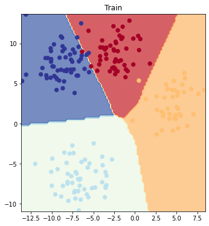

```python
plt.figure(figsize=(12,6))
plt.subplot(1,2,1)
plt.title("Train")
plot_decision_boundary(model_4, X_blob_test, y_blob_test)
```

# 9. A few more classification metrics....

1. precision
2. accuracy
3. recall
4. F-Score
5. Classification report

```python
!pip install torchmetrics
```

```python
from torchmetrics import Accuracy

torchmetric_accuracy = Accuracy(task="multiclass", num_classes=4).to(device)

torchmetric_accuracy(y_preds, y_blob_test)
```

```
tensor(0.9700)
```